# Fisseha Berhane

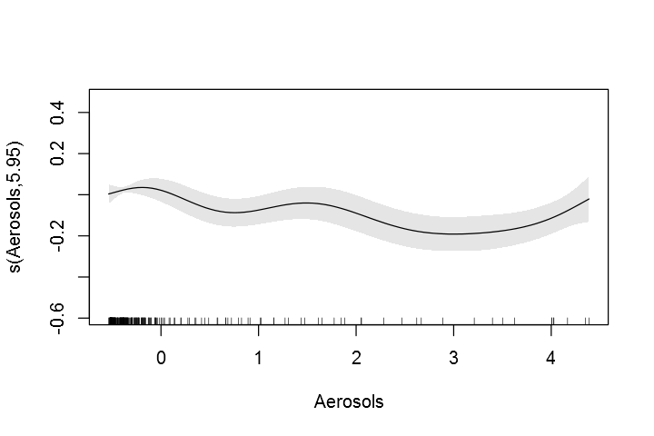

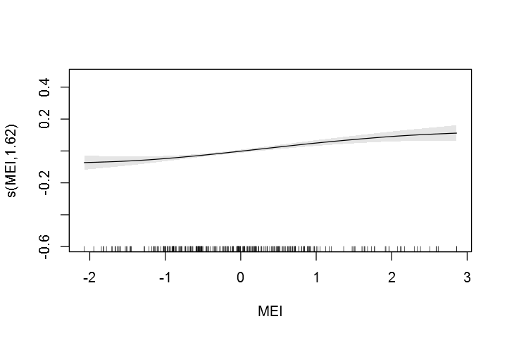

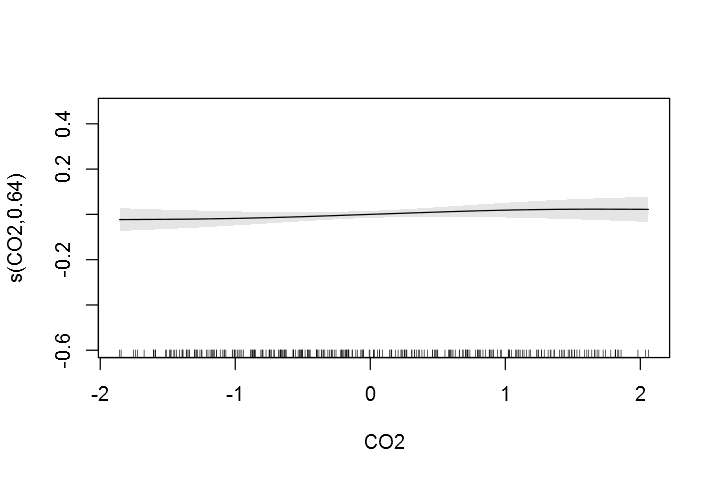

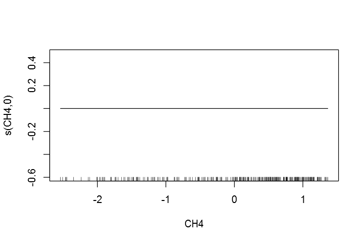

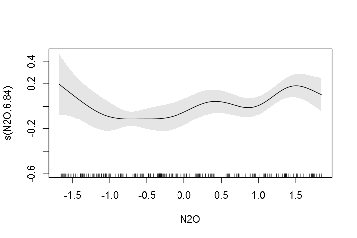

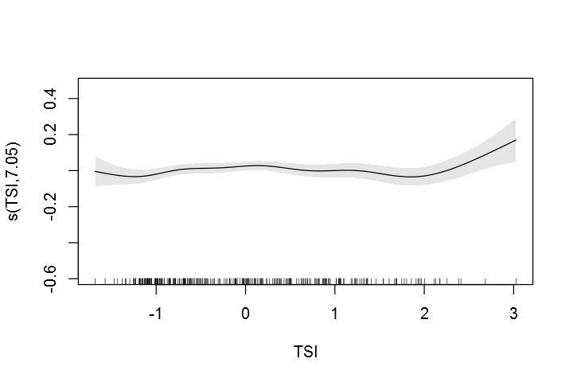

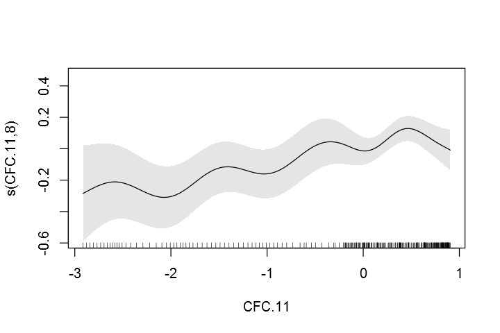

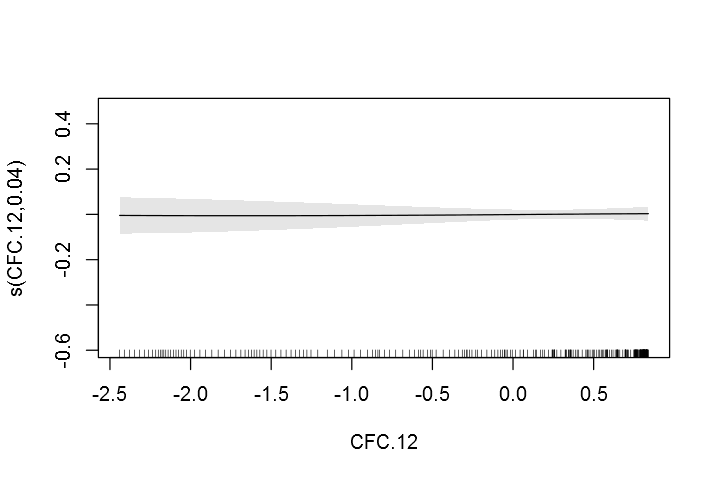

```r
plot(my_gam$finalModel, residuals=F, se=TRUE, shade=T,shade.col='gray90')
```

```
 grid:    Aerosols         MEI        CO2       CH4        N2O        TSI
         -0.383846 -0.03595218 -0.1332432 0.2794737 -0.1697432 -0.1169673
    CFC.11    CFC.12
 0.3757639 0.4720244
```

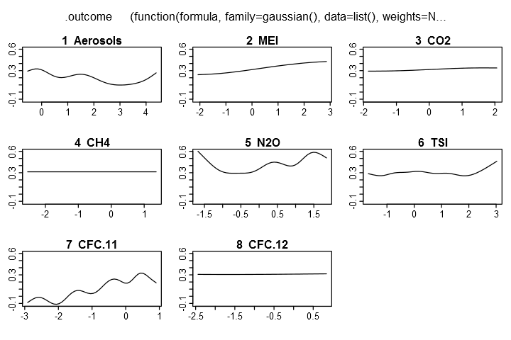

```r
plotmo(my_gam$finalModel)
```

### Multivariate Adaptive Regression Spline

```
earth variable importance

         Overall
CO2       100.00
MEI        46.25
CFC.11     40.61
CFC.12     40.61
Aerosols   30.45
N2O        22.83
TSI        16.00
CH4         0.00
```

[figure not shown]

[figure not shown]

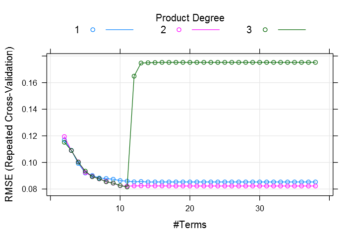

```r
# Define the candidate models to test

marsGrid <- expand.grid(.degree = 1:3, .nprune = 2:38)


control <- trainControl(method="repeatedcv", number=10, repeats=5)

# Fix the seed so that the results can be reproduced

set.seed(200)

my_mars <- train(training[,3:10], training[,11],

method = "earth",

## put the predictors on the same scale
preProc = c("center", "scale"),

# Explicitly declare the candidate models to test
tuneGrid = marsGrid,
trControl = control)

pred<-predict(my_mars,testingX)

my_data=as.data.frame(cbind(predicted=pred,observed=testingY))

ggplot(my_data,aes(predicted,observed))+geom_point()+geom_smooth(method=lm)+ggtitle('MARS')

# Print, plot variable importance

print(varImp(my_mars, scale = FALSE))

plot(varImp(my_mars, scale = FALSE), main="Variable Importance using MARS model")

plot(my_mars)
```

```r
my_mars$metric
```

"RMSE"

```r
my_mars$bestTune
```

|  | nprune | degree |
| --- | --- | --- |
| 84 | 11 | 3 |

```r
summary(my_mars)
```

```
Call: earth(x=structure(list(MEI=c(2.38165368503335, 1.96321155813768,
      1.50496902328535, 0.847724448649731, 0.0925923841747671, -0.365650150677561,
      -0.557122383550131, -0.557122383550131, -0.73245931589973, -0.975564510445801,
      -0.226886566180025, -0.0117492258737678, -0.237643433195338,
      -0.520549035698067, -0.516246288891942, -0.560349443654724, -0.45600783360619,
      -0.350590536856123, -0.745367556318106, -1.02504609871624, -0.971261763639676,
      -1.01536491840246, -1.16058262310918, -0.888433887621767, -1.1541285029,
      -0.460310580412315, -0.535608649519505, -0.789470711080889, -0.949748029609051, ...

                                         coefficients
(Intercept)                                 0.5944354
h(1.73086-MEI)                             -0.0367548
h(1.28812-CO2)                             -0.1135592
h(CFC.11-0.644612)                         -0.4965422
h(TSI-1.92997)                              0.2942713
h(1.73086-MEI) * h(TSI- -0.0145458)        -0.0273283
h(N2O-0.219559) * h(CFC.11-0.644612)       25.4799262
h(CFC.11-0.644612) * h(CFC.12-0.466317)    -6.0597052
h(CFC.11-0.644612) * h(0.466317-CFC.12)    -4.4943123
h(0.644612-CFC.11) * h(Aerosols-1.61189)   -0.0929180
h(0.644612-CFC.11) * h(1.61189-Aerosols)   -0.0546844

Selected 11 of 20 terms, and 7 of 8 predictors
Termination condition: Reached nk 21
Importance: CO2, MEI, CFC.11, CFC.12, Aerosols, N2O, TSI, CH4-unused
Number of terms at each degree of interaction: 1 4 6
GCV 0.006516736    RSS 1.527394    GRSq 0.8020795    RSq 0.8355032
```

```
 grid:    MEI        CO2       CH4        N2O    CFC.11    CFC.12        TSI
  -0.03595218 -0.1332432 0.2794737 -0.1697432 0.3757639 0.4720244 -0.1169673
  Aerosols
 -0.383846
```

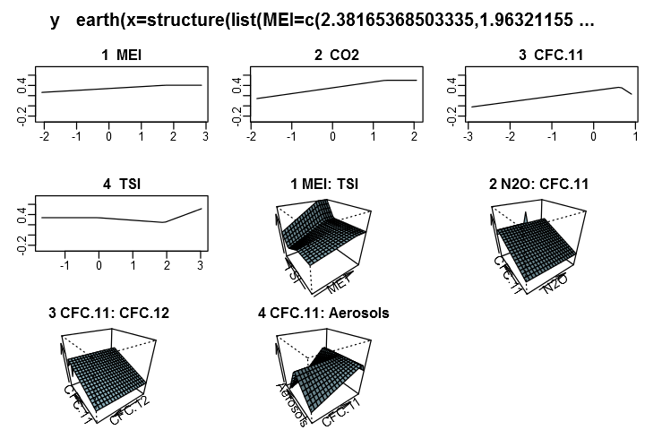

```r
plotmo(my_mars$finalModel)# plotmo(my_mars$finalModel,type="link")
```

See [Wikipedia](https://en.wikipedia.org/wiki/Multivariate_adaptive_regression_splines) to understand the interaction of the features and how the response varies keeping the other features at their median values.

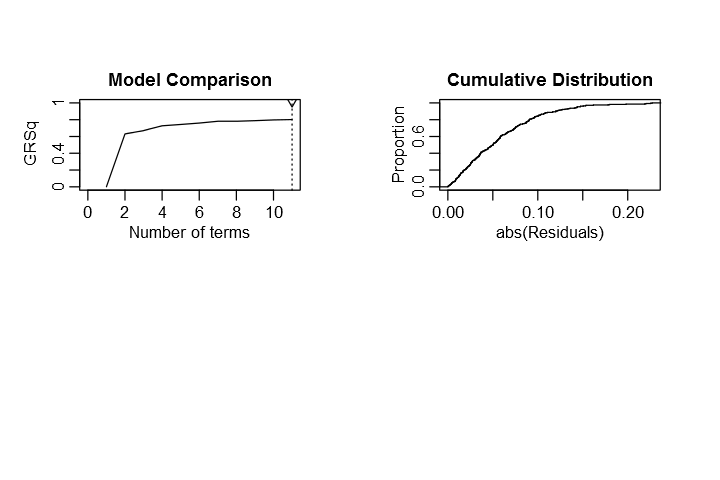

```r
plot.earth.models(my_mars$finalModel)
```

### Neural networks

To choose the number of hidden units and the amount of weight decay via resampling, the train function can be applied.

First, we remove predictors to ensure that the maximum absolute pairwise correlation between the predictors is less than 0.75.

```
loess r-squared variable importance

         Overall
CO2      0.64428
Aerosols 0.57937
CFC.11   0.49591
TSI      0.14404
MEI      0.08436
```

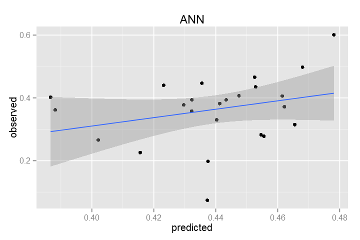

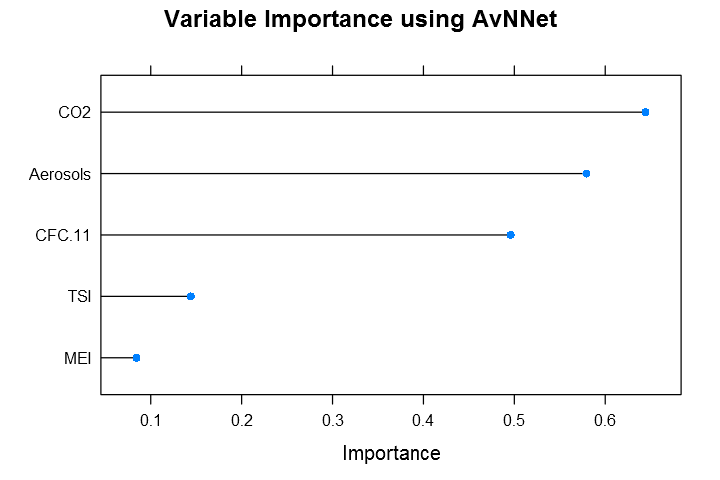

```r
# The findCorrelation takes a correlation matrix and determines the
# column numbers that should be removed to keep all pair-wise correlations below a threshold

tooHigh <- findCorrelation(cor(training[,3:10]), cutoff = .75)

trainXnnet <- training[,3:10][, -tooHigh]
testXnnet <- testing[,3:10][, -tooHigh]

## Create a specific candidate set of models to evaluate:

nnetGrid <- expand.grid(.decay = seq(0, 0.1, .01),
.size = c(3:10),

## The next option is to use bagging
## instead of different random
## seeds.
.bag = FALSE)

 set.seed(100)


control <- trainControl(method="repeatedcv", number=10, repeats=5)

my_avnnet <- train(trainXnnet, training[,11],
method = "avNNet",repeats = 10,
tuneGrid = nnetGrid,
trControl = control,
## Automatically standardize data prior to modeling and prediction
preProc = c("center", "scale"),
linout = TRUE,
trace = FALSE,
MaxNWts = 10 * (ncol(trainXnnet) + 1) + 10 + 1,
maxit = 500)

# Predict using the test data

pred<-predict(my_avnnet,testXnnet)

my_data=as.data.frame(cbind(predicted=pred,observed=testingY))

ggplot(my_data,aes(predicted,observed))+geom_point()+geom_smooth(method=lm)+ggtitle('ANN')


# Print, plot variable importance

print(varImp(my_avnnet, scale = FALSE))

plot(varImp(my_avnnet, scale = FALSE), main="Variable Importance using AvNNet")
```

Now let's visualize the neural nets used for averagig.

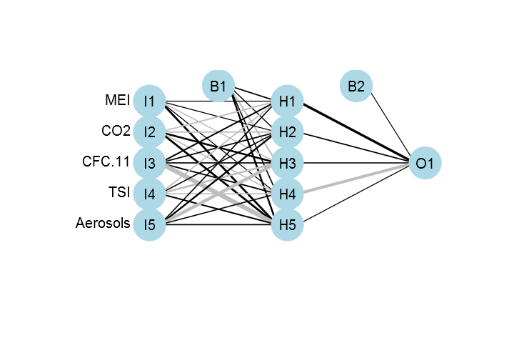

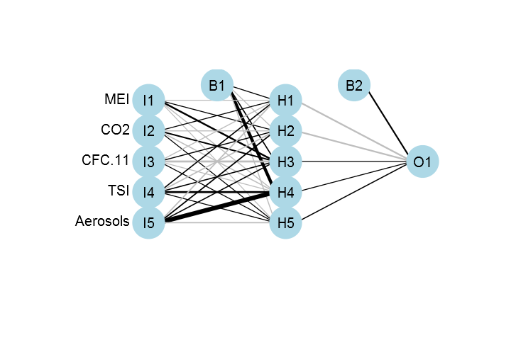

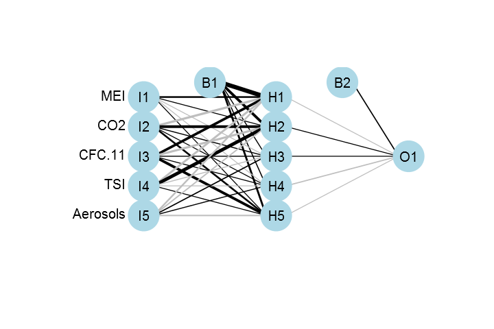

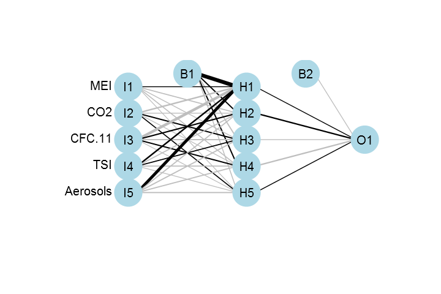

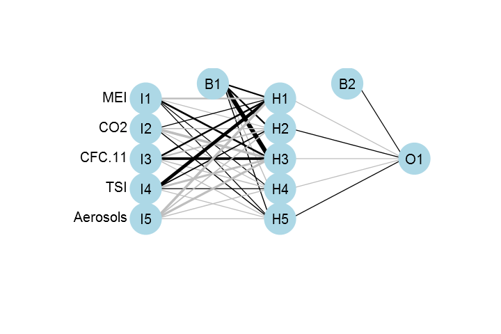

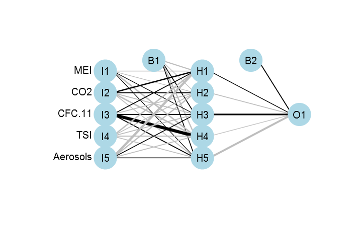

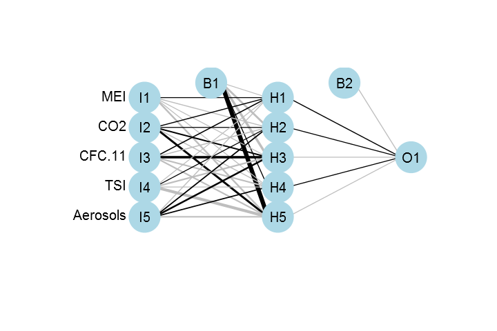

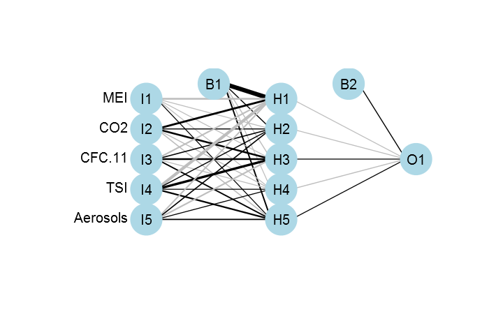

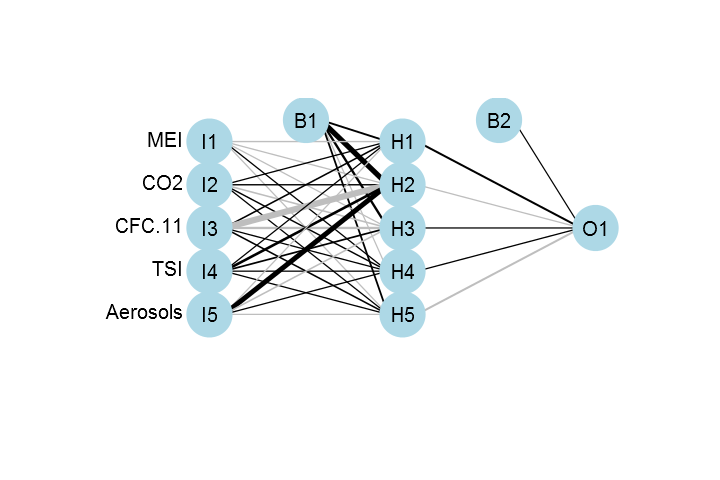

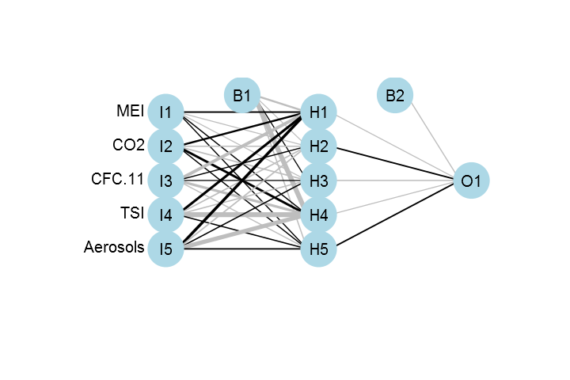

```r
for (i in 1:length(my_avnnet$finalModel$model))
     {
allmods <- my_avnnet$finalModel$model

mod <- allmods[[i]] # first model, change this number to look at the other models

wts <- mod$wts
decay <- mod$decay
struct <- mod$n

# recreate
recmod <- nnet(trainXnnet, training[,11], Wts = wts, decay = decay, size = struct[2], maxit = 0)

# use the functions to look at the individual model

plotnet(recmod)

}
```

In the above figures, the black (gray) lines correspond to positive (negative) weights.

## Support Vector Machines

There are a couple of options to work with support vector machines for regression. The details can be found from the [caret](http://topepo.github.io/caret/Support_Vector_Machines.html) website.

Here, let's use support vector machines with radial basis function kernel.

```
loess r-squared variable importance

         Overall
CFC.12   0.64706
CO2      0.64428
N2O      0.62275
Aerosols 0.57937
CH4      0.54393
CFC.11   0.49591
TSI      0.14404
MEI      0.08436
```

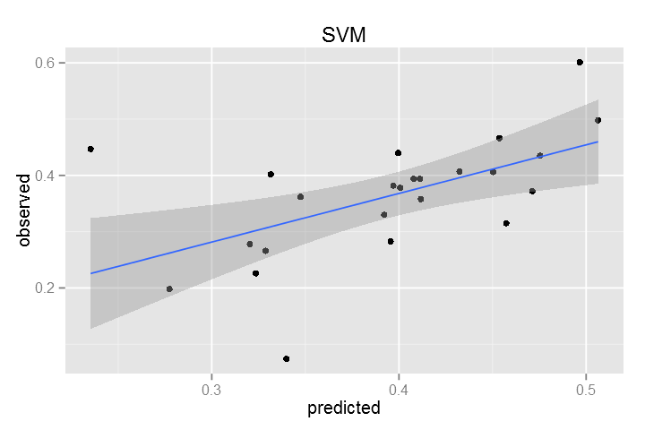

```
Length  Class   Mode
     1   ksvm     S4
```

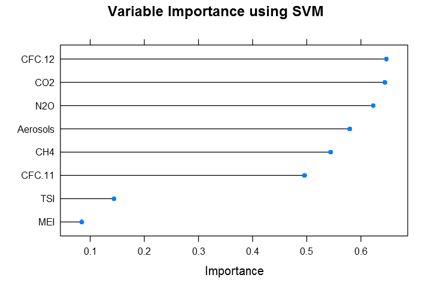

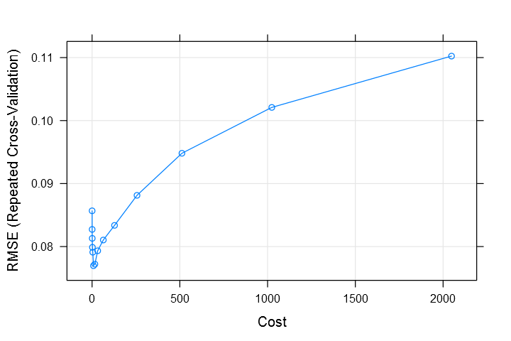

```r
control <- trainControl(method="repeatedcv", number=10, repeats=5)

my_svm <- train(training[,3:10], training[,11],
method = "svmRadial",
preProc = c("center", "scale"),
tuneLength = 14,
trControl = control)

# predict using the test data

pred<-predict(my_svm,testingX)

my_data=as.data.frame(cbind(predicted=pred,observed=testingY))

ggplot(my_data,aes(predicted,observed))+geom_point()+geom_smooth(method=lm)+ggtitle('SVM')

# Print, plot variable importance

print(varImp(my_svm, scale = FALSE))

plot(varImp(my_svm, scale = FALSE), main="Variable Importance using SVM")

summary(my_svm)

plot(my_svm)
```

## CART

```
rpart variable importance

         Overall
CFC.12     4.342
CFC.11     4.070
N2O        3.617
Aerosols   3.332
MEI        2.888
CO2        2.693
TSI        2.245
CH4        1.274
```

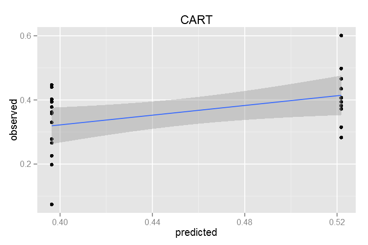

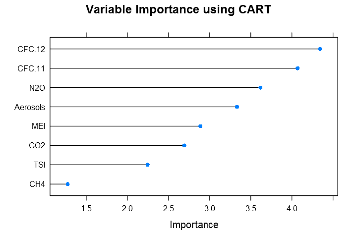

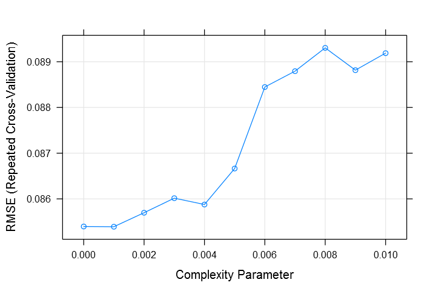

```r
control <- trainControl(method="repeatedcv", number=10, repeats=5)

cp.grid = expand.grid( .cp = (0:10)*0.001)

my_cart <- train(training[,3:10], training[,11],
method = "rpart",
preProc = c("center", "scale"),

tuneGrid = cp.grid,

trControl = control)

# predict using the test data

pred<-predict(my_cart,testingX)

my_data=as.data.frame(cbind(predicted=pred,observed=testingY))

ggplot(my_data,aes(predicted,observed))+geom_point()+geom_smooth(method=lm)+ggtitle('CART')

# Print, Plot variable importance

print(varImp(my_cart, scale = FALSE))

plot(varImp(my_cart, scale = FALSE),main="Variable Importance using CART")

plot(my_cart)
```

## Bagged CART

```
treebag variable importance

         Overall
CFC.12     2.463
N2O        2.204
Aerosols   1.988
CFC.11     1.944
CO2        1.589
MEI        1.160
TSI        1.041
CH4        1.003
```

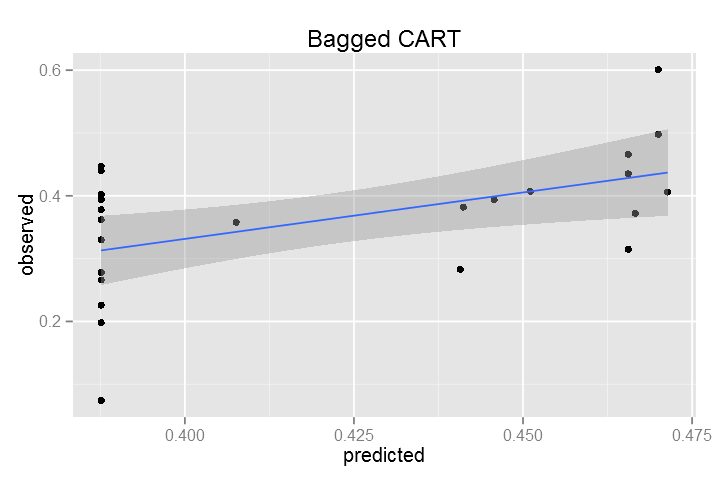

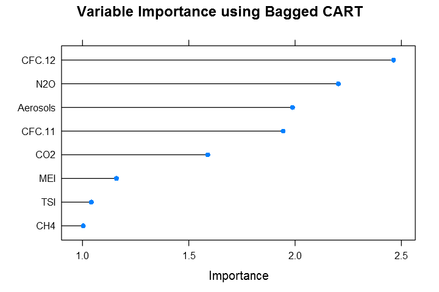

```r
control <- trainControl(method="repeatedcv", number=10, repeats=5)


my_bagged_cart <- train(training[,3:10], training[,11],
method = "treebag",
preProc = c("center", "scale"),
trControl = control)

pred<-predict(my_bagged_cart,testingX)

my_data=as.data.frame(cbind(predicted=pred,observed=testingY))

ggplot(my_data,aes(predicted,observed))+geom_point()+geom_smooth(method=lm)+ggtitle('Bagged CART')

# Print, Plot variable importance

print(varImp(my_bagged_cart, scale = FALSE))

plot(varImp(my_bagged_cart, scale = FALSE),main="Variable Importance using Bagged CART")
```

## Random Forest

```
rf variable importance

         Overall
CFC.11     23.16
MEI        22.72
CFC.12     20.22
N2O        17.94
Aerosols   17.36
TSI        16.35
CO2        12.97
CH4        11.41
```

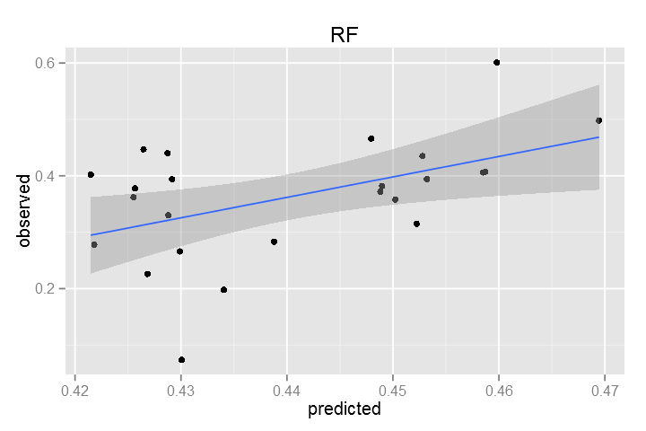

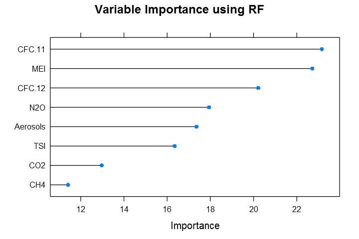

```r
control <- trainControl(method="repeatedcv", number=10, repeats=5)

my_rf <- train(training[,3:10], training[,11],
method = "rf", ntrees = 1000,importance = TRUE,
preProc = c("center", "scale"),

trControl = control)

# Predict using the test data

pred<-predict(my_rf,testingX)

my_data=as.data.frame(cbind(predicted=pred,observed=testingY))

ggplot(my_data,aes(predicted,observed))+geom_point()+geom_smooth(method=lm)+ggtitle('RF')

# Print, Plot variable importance

print(varImp(my_rf, scale = FALSE))

plot(varImp(my_rf, scale = FALSE),main="Variable Importance using RF")
```

```r
my_rf
```

```
Random Forest

284 samples
  8 predictor

Pre-processing: centered, scaled
Resampling: Cross-Validated (10 fold, repeated 5 times)

Summary of sample sizes: 254, 256, 256, 255, 256, 256, ...

Resampling results across tuning parameters:

  mtry  RMSE        Rsquared   RMSE SD     Rsquared SD
  2     0.06705281  0.8655276  0.01247509  0.04468607
  5     0.06745943  0.8635262  0.01296567  0.04692552
  8     0.06962175  0.8548274  0.01259311  0.04680029

RMSE was used to select the optimal model using  the smallest value.
The final value used for the model was mtry = 2.
```

## Stochastic Gradient Boosting

```
gbm variable importance

         Overall
CFC.12     88.85
N2O        57.13
Aerosols   33.35
CFC.11     27.62
MEI        27.20
CO2        19.53
TSI        16.19
CH4        10.02
```

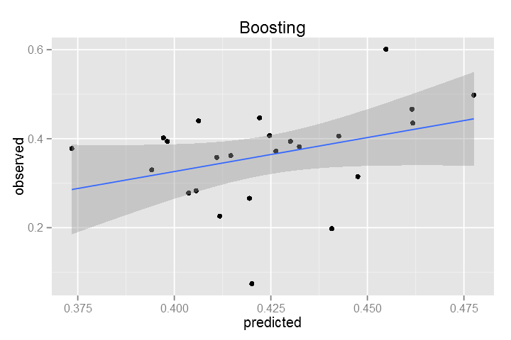

```
Time taken =  38.66062
```

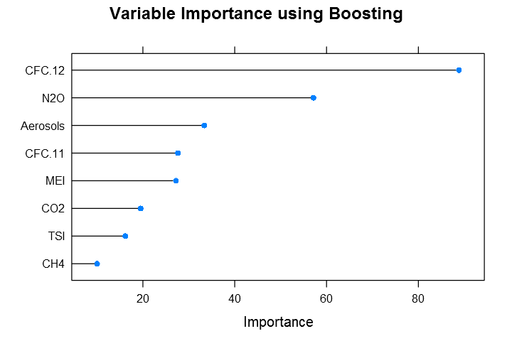

```r
# To tune over interaction depth, number of trees, and shrinkage first define a tuning grid, then train over this grid
start.time <- Sys.time()

gbmGrid <- expand.grid(.interaction.depth = c(2,5,8),
                      .n.trees = c(500, 1000,2000,5000),
                       .shrinkage = c(0.01, 0.1),
                        .n.minobsinnode=c(5,10,15))


control <- trainControl(method="repeatedcv", number=10, repeats=5)

my_boosting <- train(training[,3:10], training[,11],
                         method = "gbm",verbose=F,
                         tuneGrid = gbmGrid,
                         preProc = c("center", "scale"),
            trControl = control)

# Predict using the test data
pred<-predict(my_boosting,testingX)

my_data=as.data.frame(cbind(predicted=pred,observed=testingY))

ggplot(my_data,aes(predicted,observed))+geom_point()+geom_smooth(method=lm)+ggtitle('Boosting')

# Print, Plot variable importance

print(varImp(my_boosting, scale = FALSE))

plot(varImp(my_boosting, scale = FALSE),main="Variable Importance using Boosting")

end.time <- Sys.time()
time.taken <- end.time - start.time
cat("Time taken = ",time.taken)
```

We can use the caret package to compare the perfomance of the machine learning models we built using the train function from the caret library.

[output not shown]

[figure not shown]

[figure not shown]

```r
# collect resamples

results <- resamples(list(GLM=my_glm,sGLM=my_stepglm,PLS=my_tunedpls, Ridge_Regr=my_ridgeReg,
                          enet=my_enet ,Lasso=my_lasso,GAM=my_gam,MARS=my_mars, nnet=my_avnnet,
                          boosting=my_boosting, rf=my_rf, SVM=my_svm))

# summarize the distributions
summary(results)
# boxplots of results
bwplot(results)
# dot plots of results
dotplot(results)
```

Then, we can use different tests to assess if the performance of one model is significantly better than the others.

## Conclusion

In this project, the performance of non-linear regression models (generalized additive model, multivariate adaptive regression spline, support vector machines, neural network, classification and regression trees, boosting and random forest) in predicting average global temperature anomaly is compared with that of linear models such as generalized linear model, lasso, ridge regression and elastic net.

Generally, all considered models have similar performances but boosting and random forest seem to be slightly better. Of course, to decide if the ensemble tree techniques are significantly better than the other models in this application, hypothesis tests have to be implemented.